# Thera Bank潜在贷款用户画像分析

# 目录

- 项目背景和目的
  - 项目背景
  - 项目目的
- 数据获取、清洗和整理
  - 数据获取
  - 数据清洗和整理
    - 导入数据，数据概览
    - 认识数据集
    - 相关性分析
    - 检查缺失值
    - 检查重复值
    - 检查异常值
- 构建模型及数据可视化
  - 贷款情况二元条件分析
    - 贷款情况与收入
    - 贷款情况与信用卡还款额
    - 贷款情况与存款账户
    - 总结
  - 贷款情况多元条件分析
    - 贷款情况与收入、信用卡还款金额及是否有银行存款账户
- 总结及建议
  - 贷款用户特征总结
  - 通过AARRR漏斗模型给出营销建议

# 分析报告

## 一、项目的背景和目的

## 1.1 项目背景

- Thera Bank是一家拥有不断增长客户群的银行，这些 客户中的大多数是具有不同存款规模的储蓄客户，贷款业务的客户数量很少。为了提升公司的营收，银行希望有效的增加贷款用户数，扩大银行的贷款业务量，赚取更多的贷款利息。为此，银行随机选取了5000名客户进行了一次贷款业务营销的宣传尝试，以此希望找到潜在贷款用户的基本特征，方便以后对客户进行精准化营销，降低贷款用户转换成本。

## 1.2 项目目的

- 通过对5000名银行客户数据进行分析，主要解决以下问题：
  - 1、描述出，通过此次营销活动，潜在贷款用户主要具有哪些特征。
  - 2、通过AARRR漏斗模型进一步给出营销建议。

# 二、数据获取、清洗和整理

## 2.1 数据获取

- 本报告中所涉及数据为[Kaggle上数据集](https://www.kaggle.com/itsmesunil/bank-loan-modelling),数据量为此次营销活动的5000条客户信息，包含14个特征。

## 2.2 数据清洗和整理

```python
import numpy as np
import pandas as pd
import matplotlib.pyplot as plt
%matplotlib inline
import seaborn as sns
```

### 2.2.1 导入数据，数据概览

```python
data=pd.read_excel('C:/Users/Think/Desktop/数据分析简历/Thera Bank银行贷款客户预测数据集/Bank_Personal_Loan_Modelling.xlsx',sheet_name='Data')
```

```python
data.head()
```

|  | ID | Age | Experience | Income | ZIP Code | Family | CCAvg | Education | Mortgage | Personal Loan | Securities Account | CD Account | Online | CreditCard |
| --- | --- | --- | --- | --- | --- | --- | --- | --- | --- | --- | --- | --- | --- | --- |
| 0 | 1 | 25 | 1 | 49 | 91107 | 4 | 1.6 | 1 | 0 | 0 | 1 | 0 | 0 | 0 |
| 1 | 2 | 45 | 19 | 34 | 90089 | 3 | 1.5 | 1 | 0 | 0 | 1 | 0 | 0 | 0 |
| 2 | 3 | 39 | 15 | 11 | 94720 | 1 | 1.0 | 1 | 0 | 0 | 0 | 0 | 0 | 0 |
| 3 | 4 | 35 | 9 | 100 | 94112 | 1 | 2.7 | 2 | 0 | 0 | 0 | 0 | 0 | 0 |
| 4 | 5 | 35 | 8 | 45 | 91330 | 4 | 1.0 | 2 | 0 | 0 | 0 | 0 | 0 | 1 |

```python
data.describe().T
```

|  | count | mean | std | min | 25% | 50% | 75% | max |
| --- | --- | --- | --- | --- | --- | --- | --- | --- |
| ID | 5000.0 | 2500.500000 | 1443.520003 | 1.0 | 1250.75 | 2500.5 | 3750.25 | 5000.0 |
| Age | 5000.0 | 45.338400 | 11.463166 | 23.0 | 35.00 | 45.0 | 55.00 | 67.0 |
| Experience | 5000.0 | 20.104600 | 11.467954 | -3.0 | 10.00 | 20.0 | 30.00 | 43.0 |
| Income | 5000.0 | 73.774200 | 46.033729 | 8.0 | 39.00 | 64.0 | 98.00 | 224.0 |
| ZIP Code | 5000.0 | 93152.503000 | 2121.852197 | 9307.0 | 91911.00 | 93437.0 | 94608.00 | 96651.0 |
| Family | 5000.0 | 2.396400 | 1.147663 | 1.0 | 1.00 | 2.0 | 3.00 | 4.0 |
| CCAvg | 5000.0 | 1.937913 | 1.747666 | 0.0 | 0.70 | 1.5 | 2.50 | 10.0 |
| Education | 5000.0 | 1.881000 | 0.839869 | 1.0 | 1.00 | 2.0 | 3.00 | 3.0 |
| Mortgage | 5000.0 | 56.498800 | 101.713802 | 0.0 | 0.00 | 0.0 | 101.00 | 635.0 |
| Personal Loan | 5000.0 | 0.096000 | 0.294621 | 0.0 | 0.00 | 0.0 | 0.00 | 1.0 |
| Securities Account | 5000.0 | 0.104400 | 0.305809 | 0.0 | 0.00 | 0.0 | 0.00 | 1.0 |
| CD Account | 5000.0 | 0.060400 | 0.238250 | 0.0 | 0.00 | 0.0 | 0.00 | 1.0 |
| Online | 5000.0 | 0.596800 | 0.490589 | 0.0 | 0.00 | 1.0 | 1.00 | 1.0 |
| CreditCard | 5000.0 | 0.294000 | 0.455637 | 0.0 | 0.00 | 0.0 | 1.00 | 1.0 |

### 2.2.2 认识数据集

- 分析数据集中每个字段的含义

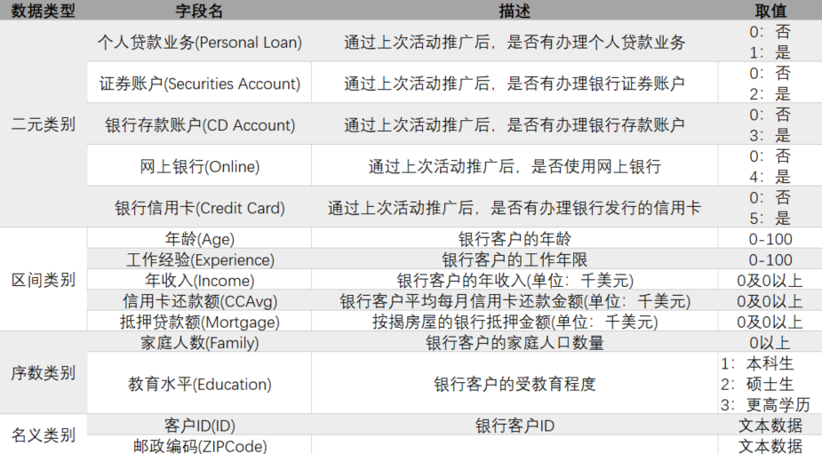

### 2.2.3 相关性分析

- 分析哪些因素影响普通银行客户转化为贷款客户

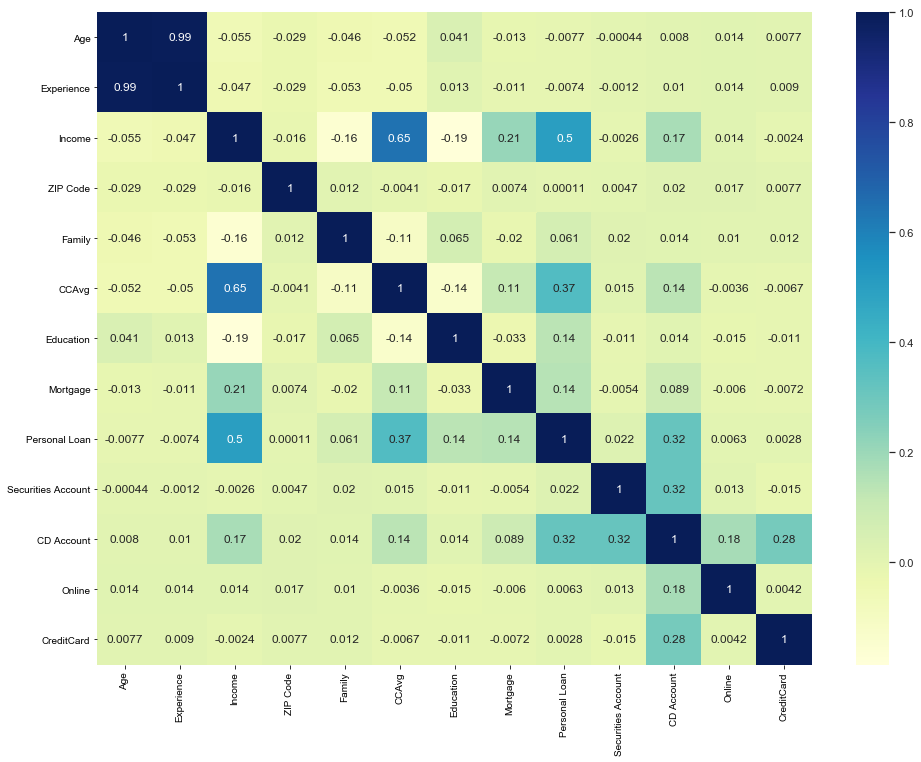

```python
f, ax = plt.subplots(figsize=(16, 12))
sns.set()
sns.heatmap(data.drop('ID',axis=1).corr(),annot=True,cmap='YlGnBu')
```

- 从图中可以看出：
  - 对贷款影响比较强的因素有：income(年收入)、CCAvg(信用卡还款额)和CD Account(是否有该银行的存款账户)。
  - 对贷款影响比较弱的因素有：Family(家庭成员数)、Education(教育程度)和Mortgage(房屋抵押贷款额)。
  - Age(年龄)、Experience(工作经验)、ZIPCode(邮政编码)、Securities Account(证券账户)、Online(是否开通网上银行)和CreditCard(是否拥有信用卡)关系都不大

### 2.2.4 检查缺失值

```python
data.apply(lambda x: len(x))
```

```
ID                    5000
Age                   5000
Experience            5000
Income                5000
ZIP Code              5000
Family                5000
CCAvg                 5000
Education             5000
Mortgage              5000
Personal Loan         5000
Securities Account    5000
CD Account            5000
Online                5000
CreditCard            5000
dtype: int64
```

- 可以看出每个字段的记录都是5000，不存在缺失值

### 2.2.5 检查重复值

```python
data.apply(lambda x: len(x.unique()))
```

```
ID                    5000
Age                     45
Experience              47
Income                 162
ZIP Code               467
Family                   4
CCAvg                  108
Education                3
Mortgage               347
Personal Loan            2
Securities Account       2
CD Account               2
Online                   2
CreditCard               2
dtype: int64
```

- 根据客户ID可以看出，数据集中共有5000个客户信息，不存在重复。

### 2.2.6 检查异常值

- 通过观察数据集可知，发现工作经验存在负值，共有52条记录。根据前期贷款因素相关性分析可知，工作经验与是否贷款之间的皮尔逊相关系数为-0.0074,基本不存在相关性，且异常值样本占全部数据集的0.0104，则对具有异常值的记录进行删除，不予讨论。

# 三、构建模型及数据可视化

## 3.1 贷款情况与各特征变量分析

- 从前期分析可知，客户年收入、每月信用卡还款额和是否拥有该银行的存款账户直接影响着贷款客户的转化率，我们接下来将分别查看这三者与贷款客户之间的关系

### 3.1.1 客户年收入与贷款客户之间的关系

- 客户的年收入最小值8000美元，最大值为224000美元，因此按照30000美元为一个区间，使用Excel绘制不同区间内总人数、贷款人数及占比的关系表格，并根据绘制的关系表格绘制出随着客户年收入的不断增加的情况下，贷款用户个数的趋势变化图。

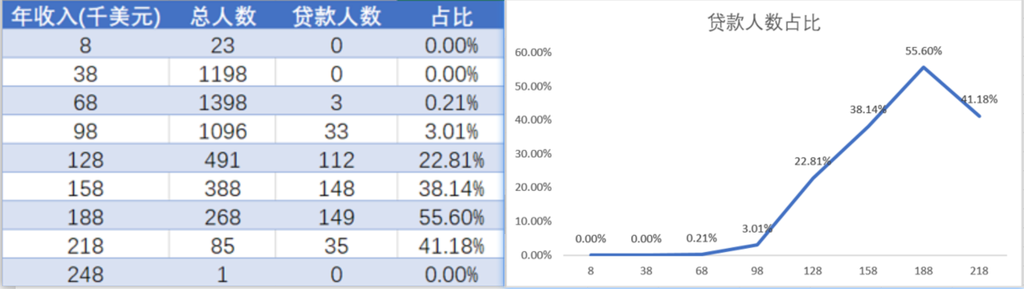

### 3.1.2 信用卡还款额与贷款用户之间的关系

- 观察数据可知，客户每月信用卡还款金额最小值为0美元，最大值为10000美元，现以2000美元作为一个区间，将信用卡还款金额分为5个区间，绘制不同区间内普通客户数与贷款客户数之间关系表格，再根据表格绘制出，还款金额与贷款用户数之间的趋势图。

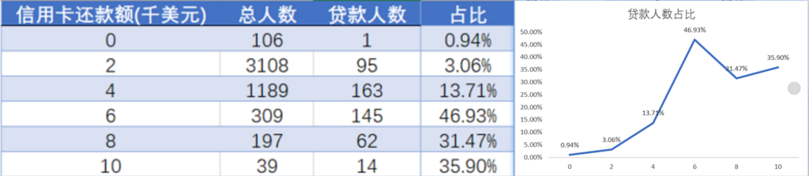

### 3.1.3 是否有该银行存款账户与贷款用户之间的关系

- 通过绘制一行银行存款账户与贷款客户之间的关系表格:

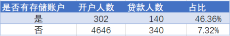

- 可知：在存款用户的银行客户中，贷款人数占其46.36%。在非银行存款用户的银行狗客户中，贷款人数占其7.32%。前者是后者的6.33倍，贷款人数比例远高于后者。

### 3.1.4 总结

- 通过分别分析客户年收入、信用卡每月还款额及客户是否有该银行存款账户与银行贷款客户之间的关系，发现：
  - 年收入在(158000-188000)美元区内的客户贷款意愿最强。
  - 信用卡每月还款额在(4000-6000)美元区间内的客户，更倾向于贷款。
  - 在该银行有存款账户的客户，更愿意在该银行办理贷款。
- 综上所述，银行在进行贷款用户营销活动时，应最先考虑具有以上三个特征的客户。达到以最低的营销成本提高银行的贷款客户数。

## 3.2 贷款情况多元条件分析

- 由上述分析可知银行贷款客户中最鲜明的三个主要特征，但在实际营销活动中，应具体明确哪一类客户群更容易转化为银行贷款客户，这样可以提高营销活动的转化率，更有效的降低转化成本，使得营销活动更加有的放矢。
- 故，在以下的分析中，将综合考虑客户年收入、信用卡还款金额及是否有银行存款这三个特征，从客户群众找出潜在贷款客户的具体特征。

### 3.2.1 贷款情况与年收入、信用卡还款金额及是否有银行储蓄账户综合分析

- 通过综合分析信用卡还款金额、年收入及是否与有储蓄账户与贷款情况的分析可知：

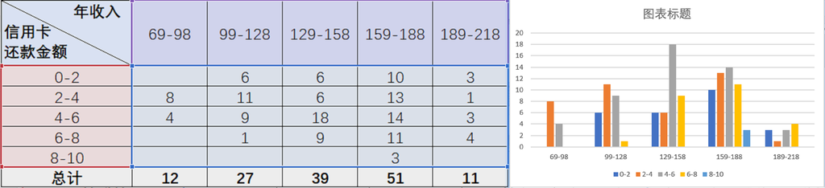

- 在有该银行储蓄账户的客户中，年收入在(129000-158000)美元区间内并且每月信用卡还款金额在(4000-6000)美元区间内的客户中，贷款客户人数最多，也就说，在这两个区间内的潜在贷款客户最多。
- 由上图我们也可发现，在年收入(159000-188000)美元区间内，除还款金额在(4000-6000)美元分组内，贷款人数相较于其他收入区间来说，贷款人数都是最多的，这也与前期分析相符。

# 四 总结及建议

## 4.1 总结

- 经分析，对以下三类客户进行贷款营销，贷款客户转化成本最低：
  - 年收入在(159000-188000)美元区间内客户群
  - 每月信用卡还款额在(4000-6000)美元区间内客户群
  - 具有该银行存款账户的客户群
- 在以上三类客户中，同时具有该银行存款账户、年收入在(129000-158000)美元且信用卡还款金额在(4000-6000)的普通客户，最容易转化为贷款客户。银行应重点面向此类客户开展贷款营销活动。

## 4.2 通过AARRR漏斗模型给出营销建议

### 4.2.2 激活贷款客户的营销建议

- 可以将银行全部的贷款客户数据，进行模型预测，从而可以让信贷部门进行更精准的贷款业务推送，降低营销成本，提高贷款客户转化率。

### 4.2.3 贷款客户留存营销建议

- 在贷款流程方面，面对二次贷款的客户，应优化贷款审批流程，并根据前期还贷情况有针对性的提高贷款额度，并且在还贷期限上，如果达到指定的还贷期限，可以降低贷款利率。
- 在贷款产品方面，在前其模型预测的基础上及参考金融市场上其它银行的信贷品，增加信贷产品的种类，满足不同人群的贷款需求
- 在还款流程面，应对贷款者进行适当地还款提醒，帮助还款者进行按时还款。并适时现场举办金融知识讲座或通过手适时推送一些理财知识，提高还款者的金融意识。

### 4.2.4 贷款客户推荐的营销建议

- 在增加贷款客户方面，一方面银行需要重点挖掘新客户和留存老客户。另一方面利用老客户吸引新客户也是一个不错的选择，在前期为贷款客户举办金融知识讲座的同时，为吸引其朋友前来参加讲座的老贷款客户，可以后期给予贷款利率优惠。对于前来参加的潜在贷款者，不仅可以获得精美礼品，在后其办理贷款时也可适当贷款利率优惠。